# 01 - R Programming

David Zimmermann

2016-10-07

# Outline

# Outline

1. Basic Data Types
2. Math & Boolean Operators
3. Control Statements
4. Basic Data Structures
5. Loops
6. Matrizes
7. Lists
8. Functions
9. Libraries
10. Style & Organization

# Basic Data Types

# Data Types

R knows four* basic types:

1. `numeric`: numbers such as `1`, `-2`, `1.414`, or `3.141`
2. `character`: strings/texts such as `"Hello world!"` or `"1"`
3. `logical`: `TRUE` or `FALSE` (`T` or `F` in short)
4. `integer`: “whole” numbers `1L`, `3L`, `-12L`

Additional: `NA`s, `Inf` (?)

For the sake of completeness: `complex`, (`factor`)

# Data Types cont’d

We can use the `class`-function to check the type (class) of anything in R

```r
class(3.141)
```

```
## [1] "numeric"
```

```r
class("hello world")
```

```
## [1] "character"
```

```r
class(TRUE)
```

```
## [1] "logical"
```

If we need help about a function just type `?foo` (i.e., `?class`)

# Variables

Assignt values to a variable using the assignment-operator `<-` to use the data later

```r
x <- 3
x
```

```
## [1] 3
```

```r
x + 2
```

```
## [1] 5
```

```r
x <- "Hello World!"
x
```

```
## [1] "Hello World!"
```

# Exercises: Data Type

```r
# Not a class, but very important: Comments...
# Everything that comes after a pound-sign (#)
# is disregarded by the programm and is room for you
# to describe what and why you are doing something

class(-123)      # 1
class(123.456)   # 2
class("123")     # 3
class("TRUE")    # 4
class("female")  # 5
class(T)         # 6
class(FALSE)     # 7
```

# Exercises: Variables

```r
x <- 120
x <- x / 2
x <- x + 4
x <- sqrt(x)
x # ?
```

# Basic Math & Boolean Operators

# Simple Math

As simple as using: `+`, `-`, `*`, `/`, `^`, `sqrt()`, `log()`, `exp()`, `%%`, `%/%`

```r
1 + 1 - 2
```

```
## [1] 0
```

```r
42 / (2 * 3)
```

```
## [1] 7
```

```r
sqrt(4 ^ 3)
```

```
## [1] 8
```

# Comparing Numbers

Using boolean operators: `==`, `!=`. `<`, `>`, `>=`, `<=`, `!`, `%in%`

```r
4 == 2
```

```
## [1] FALSE
```

```r
3 != 2
```

```
## [1] TRUE
```

```r
2 < 2
```

```
## [1] FALSE
```

```r
2 >= 2
```

```
## [1] TRUE
```

# Comparing Numbers cont’d

Negation (reversing the outcome) can be done with `!`

```r
!(2 < 4)
```

```
## [1] FALSE
```

```r
!TRUE
```

```
## [1] FALSE
```

# Simple Math nesting

Evaluating multiple statements through nesting:

(using logical `&` AND, or `|` OR)

```r
T & T
```

```
## [1] TRUE
```

```r
T | F
```

```
## [1] TRUE
```

```r
(10 < 5) & (2 < 5); (10 < 5) | (2 < 5)
```

```
## [1] FALSE
```

```
## [1] TRUE
```

# Exercises: Math

Find the solutions to

$$x = 3 * log(2980.958)$$

$$y = \sqrt{1764}$$

$$z = \frac{e^{7.475339}}{20^2 - 358}$$

Hint: `exp()`, `sqrt()`, and `log()`

# Exercises: Logic

```r
5 < 4                   # 1
24 >= sqrt(576)         # 2
!(23 < sqrt(123))       # 3
((4 - 5) ^ 2 + 1) > 0   # 4
(T & F) | (T & T)       # 5
!(!(3 + 5 < 8) | 2 > 5) # 6
```

# Control Statements

# IF-statements Blueprint

```r
# IF-Statements
if (test) {
  # run this if test == TRUE
  ...
} else if (test2) {
  # run this if test != TRUE and test2 == TRUE
  ...
} else {
  # else: run this
  ...
}
```

# IF-example

```r
x <- 99
if (x < 0) {
  print(paste(x, "is smaller than 0"))
} else if (x < 10) {
  print(paste(x, "is smaller than 10 and larger than or equal to 0"))
} else if (x < 100) {
  print(paste(x, "is smaller than 100 and larger than or equal to 10"))
} else {
  print(paste(x, "is larger than or equal to 100"))
}
```

```
## [1] "99 is smaller than 100 and larger than or equal to 10"
```

# Cash Register

Say we have built a cash register for different products Questions: What is the tax if we have a variable `product` that is either `book` (7% VAT) or `PC` (19% VAT).

```r
product <- "book"

if (product == "book") {
  print("VAT is 7%")
} else if (product == "PC") {
  print("VAT is 19%")
} else {
  print("Unknown product")
}
```

# Engineering Flow-Chart

```r
does_it_move <- T
should_it_move <- F

if (does_it_move){ # it moves
  if (should_it_move) { # it should move
    print("Everything fine!")
  } else { # it shouldnt move
    print("Use duck tape!")
  }
} else { # it doesnt move
  if (should_it_move) { # it should move
    print("Use WD-40!")
  } else {# it shouldnt moce
  print("Everything fine!")
  }
}
```

# Exercise

1. Evaluate both the cash register and the engineering flow-chart in R and test multiple cases.
2. Write an if-statement that checks if a given number is odd or even.
3. Write an if-statement that takes the temperature and gives recommendations on what to wear (min. 3 cases).

# Basic Data Structures

# Vectors

So far only single values… realistic? Solution (one-dimensional) vector

Concatenate values to vector with `c()`.

```r
c(1, 3, 5, 7)
```

```
## [1] 1 3 5 7
```

Caveat: A vector has always the same class

```r
c(1, 3, T, "cat")
```

```
## [1] "1"    "3"    "TRUE" "cat"
```

# Vector Length and Extending

`length()` returns the size of the vector

```r
vec <- c(1, 2, 3, 52, NA, 123)
length(vec)
```

```
## [1] 6
```

Extending a vector using `c()` as well

```r
vec <- c(vec, 7)
vec
```

```
## [1]   1   2   3  52  NA 123   7
```

# Accessing a Vector

How do we access only a single element of a vector? -> `[]`

```r
vec <- c(6, 4, 2, 5, 16, 7)
vec
```

```
## [1]  6  4  2  5 16  7
```

```r
vec[1]
```

```
## [1] 6
```

```r
vec[7] # Out of bounds!
```

```
## [1] NA
```

# Accessing a Vector cont’d

More advanced access methods using `vec <- c(6, 4, 2, 5, 16, 7)`

```r
vec[c(6, 4, 5)] # take elements 6, 4, 5
```

```
## [1]  7  5 16
```

```r
vec[c(T, T, F, F, F, T)] # take elements T (1, 2, 6)
```

```
## [1] 6 4 7
```

```r
vec[vec > 5] # take all elements larger than 5
```

```
## [1]  6 16  7
```

# Vectors Sequences

Creating a sequence of numbers using `:` or using `seq`

```r
0:10
```

```
##  [1]  0  1  2  3  4  5  6  7  8  9 10
```

```r
seq(from = 0, to = 5, by = 0.5)
```

```
##  [1] 0.0 0.5 1.0 1.5 2.0 2.5 3.0 3.5 4.0 4.5 5.0
```

```r
seq(0, 100, length.out = 11)
```

```
##  [1]   0  10  20  30  40  50  60  70  80  90 100
```

# Comparing Values in a Vector

Checking if an element is in another vector using `%in%`

```r
3 %in% 1:10
```

```
## [1] TRUE
```

```r
0.5 %in% 0:10
```

```
## [1] FALSE
```

```r
"Dave" %in% c("Alice", "Bob", "Charlie", "David")
```

```
## [1] FALSE
```

# Vector Repetitions

```r
LETTERS[1:10]
```

```
##  [1] "A" "B" "C" "D" "E" "F" "G" "H" "I" "J"
```

```r
rep(LETTERS[1:2], 2)
```

```
## [1] "A" "B" "A" "B"
```

```r
rep(LETTERS[1:2], each = 2)
```

```
## [1] "A" "A" "B" "B"
```

# Vector Math Functions

```r
# check ?Random
x <- rnorm(100) # creates 100 normal-distributed random values
sum(x); min(x); max(x); range(x); mean(x); median(x); sd(x); var(x)
```

```
## [1] -2.35188
```

```
## [1] -2.656776
```

```
## [1] 2.967185
```

```
## [1] -2.656776  2.967185
```

```
## [1] -0.0235188
```

```
## [1] -0.05488029
```

```
## [1] 0.9434354
```

```
## [1] 0.8900703
```

# Vector Math Functions cont’d

```r
# check ?Random
y <- runif(100) # creates 100 uniform-distributed random values
cor(x, y)
```

```
## [1] 0.07592529
```

```r
cov(x, y)
```

```
## [1] 0.02030446
```

# Vectorisation

Powerful feature of R: Vectorisation.

```r
vec <- 0:8
vec ^ 2
```

```
## [1]  0  1  4  9 16 25 36 49 64
```

```r
vec == 2
```

```
## [1] FALSE FALSE  TRUE FALSE FALSE FALSE FALSE FALSE FALSE
```

```r
vec < 5
```

```
## [1]  TRUE  TRUE  TRUE  TRUE  TRUE FALSE FALSE FALSE FALSE
```

```r
# element-wise comparison
c(1, 3, 4, 6) == c(2, 3, 4, 7)
```

```
## [1] FALSE  TRUE  TRUE FALSE
```

# Vectorisation ifelse

```r
vec <- c(10, -3, 12, -8, 8)
ifelse(vec < 0, -vec, vec) # vectorised if-else-statement
```

```
## [1] 10  3 12  8  8
```

```r
# Or nested ifelse statements
ifelse(vec < 0, -vec, ifelse(vec < 10, 10, 20))
```

```
## [1] 20  3 20  8 10
```

# Recap - Vector

```r
x <- c(1, 2, 3)
x <- 1:3 # in this case same as above
x <- seq(from = 1, to = 3, by = 1) # in this case same as above
x <- seq(1, 3, 1) # same as above
x <- seq(1, 3, length.out = 3) # in this case same as above
x
```

```
## [1] 1 2 3
```

```r
x[(x < 2) | (x / 2 == 1.5)]
```

```
## [1] 1 3
```

# Recap - Vector

```r
LETTERS[1:15]
```

```
##  [1] "A" "B" "C" "D" "E" "F" "G" "H" "I" "J" "K" "L" "M" "N" "O"
```

```r
rep(LETTERS[1:8], each = 2)
```

```
##  [1] "A" "A" "B" "B" "C" "C" "D" "D" "E" "E" "F" "F" "G" "G" "H" "H"
```

```r
vec_name <- c("Alice", "Bob")
paste("Hi", vec_name)
```

```
## [1] "Hi Alice" "Hi Bob"
```

# Exercises Vector

Given that we have a vector of weight of 10 grownups:

`ppl <- c(67, 98, 85, 1, 71, 59, 55, 49, 79, -99)`

1. Clean the data (take realistic values).
2. Find the mean, max, min, median, and the standard-deviation.
3. What is the mean weight for people above 67 kg?

# Loops

# For-loop

Blueprint of a for-loop, where `var` is the name of a (not-yet used) variable and `values` is a vector

```r
for (var in values) {
  # do something
  ...
}
```

Example:

```r
for (i in 1:3) {
  print(paste("i is now", i))
}
```

```
## [1] "i is now 1"
## [1] "i is now 2"
## [1] "i is now 3"
```

# For-loop cont’d

`var` and `values` can take many forms

```r
class_names <- c("Alice", "Bob", "Charlie", "Dave")

for (name in class_names) {
  print(paste("Hello", name, "your name has", nchar(name), "letters!"))
}
```

```
## [1] "Hello Alice your name has 5 letters!"
## [1] "Hello Bob your name has 3 letters!"
## [1] "Hello Charlie your name has 7 letters!"
## [1] "Hello Dave your name has 4 letters!"
```

# Exercises

1. Use a for-loop to count the number of names in `class_names` that have more than 4 letters
2. Calculate:
   $$\sum^{10}_{i = 0} (3^i - i^3)$$
   using a for-loop. Compare that to a vectorised approach.
3. Calculate:
   $$\sum^{10}_{i = 0} \sum^{20}_{j = 0} \frac{j ^ i}{(j - i)^2} + log(j)*i$$

# Matrix

# Matrices

Vector: One-dimensional, what about two-dimensional? -> Matrix

```r
mat <- matrix(1:9, nrow = 3, byrow = T)
mat
```

```
##      [,1] [,2] [,3]
## [1,]    1    2    3
## [2,]    4    5    6
## [3,]    7    8    9
```

```r
mat > 2; mat[1, 2]
```

```
##       [,1]  [,2] [,3]
## [1,] FALSE FALSE TRUE
## [2,]  TRUE  TRUE TRUE
## [3,]  TRUE  TRUE TRUE
```

```
## [1] 2
```

# Matrices Functions

`length()` returns the length, not the dimension of the matrix, thus usage of `dim()` (returns rows and columns in that order)

```r
dim(mat)
```

```
## [1] 3 3
```

Another useful function to look at the structure of the element is `str()`

```r
str(mat)
```

```
##  int [1:3, 1:3] 1 4 7 2 5 8 3 6 9
```

# Matrix-Specific Functionality

Comprehensive list of matrix-functions:

http://www.statmethods.net/advstats/matrix.html

```r
mat %*% mat       # matrix multiplication
```

```
##      [,1] [,2] [,3]
## [1,]   30   36   42
## [2,]   66   81   96
## [3,]  102  126  150
```

```r
t(mat); diag(mat) # transpose and take the diagonal
```

```
##      [,1] [,2] [,3]
## [1,]    1    4    7
## [2,]    2    5    8
## [3,]    3    6    9
```

```
## [1] 1 5 9
```

# Recap - Matrix

```r
mat <- matrix(1:12, nrow = 3, ncol = 4, byrow = F)
mat[, 4]
```

```
## [1] 10 11 12
```

```r
mat[2, ]
```

```
## [1]  2  5  8 11
```

```r
mat[2, 4]
```

```
## [1] 11
```

# Recap - Matrix cont’d

```r
dim(mat)
```

```
## [1] 3 4
```

```r
mat %*% t(mat)
```

```
##      [,1] [,2] [,3]
## [1,]  166  188  210
## [2,]  188  214  240
## [3,]  210  240  270
```

```r
diag(mat)
```

```
## [1] 1 5 9
```

# Lists

# List Intro

Slot-system with n-dimensions (nesting), which can contain everything (i.e., atomic, vector, matrix, other list and more complex data structures)

```r
book1 <- list(product = "Book",
            title = "Weapons of Math Desctruction",
            value = 19.99,
            authors = list(firstname = "Cathy", lastname = "O'Neil"))

str(book1)
```

```
## List of 4
##  $ product: chr "Book"
##  $ title  : chr "Weapons of Math Desctruction"
##  $ value  : num 20
##  $ authors:List of 2
##   ..$ firstname: chr "Cathy"
##   ..$ lastname : chr "O'Neil"
```

# List Print

```r
book1
```

```
## $product
## [1] "Book"
##
## $title
## [1] "Weapons of Math Desctruction"
##
## $value
## [1] 19.99
##
## $authors
## $authors$firstname
## [1] "Cathy"
##
## $authors$lastname
## [1] "O'Neil"
```

# List Access

Access using `$` followed by item name

```r
book1$title
```

```
## [1] "Weapons of Math Desctruction"
```

```r
book1$authors$lastname
```

```
## [1] "O'Neil"
```

# List Access cont’d

Or access using `[]` followed by number. Be aware of difference between `[]` and `[[]]`

```r
book1[2]
```

```
## $title
## [1] "Weapons of Math Desctruction"
```

```r
book1[[2]]
```

```
## [1] "Weapons of Math Desctruction"
```

# List of Lists

```r
products <- list(book1,
                 book1)
str(products)
```

```
## List of 2
##  $ :List of 4
##   ..$ product: chr "Book"
##   ..$ title  : chr "Weapons of Math Desctruction"
##   ..$ value  : num 20
##   ..$ authors:List of 2
##   .. ..$ firstname: chr "Cathy"
##   .. ..$ lastname : chr "O'Neil"
##  $ :List of 4
##   ..$ product: chr "Book"
##   ..$ title  : chr "Weapons of Math Desctruction"
##   ..$ value  : num 20
##   ..$ authors:List of 2
##   .. ..$ firstname: chr "Cathy"
##   .. ..$ lastname : chr "O'Neil"
```

# Recap basic data structures

1. vectors: one-dimensional, one type
2. matrix: two-dimensional, one type
3. list: n-dimensional, depending on slot
4. … more tomorrow

# Exercises List

1. Create some more products (put them all in a `products`-list)
2. Use a for-loop and calculate the gross-price of the products (use an if-statement for the VAT)

# Functions

# What is a function?

> Don’t repeat yourself!

Idea: write the code once in a function, call the function as often as needed

Functions - Take inputs, produce outputs…

```r
foo <- function() {
  # do something
  ...
}
```

```r
print_fun <- function(text) {
  print(text)
}
print_fun("This is a text!")
```

```
## [1] "This is a text!"
```

```r
rep_print <- function(text, n) {
  print(rep(text, n))
}
rep_print("This is a text", 2)
```

```
## [1] "This is a text" "This is a text"
```

Also possible (naming the input and thus ordering):

```r
rep_print(n = 2, text = "This is a text")
```

```
## [1] "This is a text" "This is a text"
```

# Default Inputs

```r
rep_print <- function(text, n = 10) {
  print(rep(text, n))
}
rep_print("This is getting annoying!") # no n provided, take the default
```

```
##  [1] "This is getting annoying!" "This is getting annoying!"
##  [3] "This is getting annoying!" "This is getting annoying!"
##  [5] "This is getting annoying!" "This is getting annoying!"
##  [7] "This is getting annoying!" "This is getting annoying!"
##  [9] "This is getting annoying!" "This is getting annoying!"
```

# Outputs

```r
standardize <- function(vec){
  std_vec <- (vec - mean(vec)) / sd(vec)
  return(std_vec)
}

x <- rnorm(10, mean = 10, sd = 5)
x_std <- standardize(x)
x_std; mean(x_std); sd(x_std)
```

```
##  [1]  0.2035400 -0.6943992 -0.2628780  1.5161001 -1.3901451  1.3207770
##  [7] -0.4112152 -0.8896956  1.1059320 -0.4980160
```

```
## [1] 2.764716e-18
```

```
## [1] 1
```

More than one value-type as an output? -> list

# Scoping

Each function has its own environment, thus variables are set only locally

```r
x <- 42

set_x <- function(n) {
  x <- n
}
set_x(123)
x
```

```
## [1] 42
```

# Scoping 2

But values can (but should not) be taken from parent-environments

```r
x <- 42

find_x <- function() {
  print(paste("x is", x))
  # no x in this env, go to parent env
}
find_x()
```

```
## [1] "x is 42"
```

# Solution to the gross-list-problem

```r
calc_gross <- function(item){
  # calculates the gross-value for a product
  if (item$product == "Book") {
    tax <- 0.07
  } else {
    tax <- 0.19
  }
  gross <- item$value / (1 + tax)
  return(gross)
}

# calculate the gross-value
book1$gross_value <- calc_gross(book1)
book1$gross_value
```

```
## [1] 18.68224
```

# Recap: Functions

```r
# Basic Function
foo <- function(){
  ...
}
# Function Arguments
foo2 <- function(arg1, arg2){
  ...
}
# Default Parameters
foo3 <- function(arg1 = 3){
  ...
}
# Returning Values
foo4 <- function(){
  ...
  return(ret_values)
}
```

# Exercises Functions

Write a function

1. `greetings`, that takes the user’s name `name` and prints a greeting.
2. `check_values`, that takes a list of products and calculates their gross-value (if not already present)
3. `fact_fun`, that computes the factorial of an input `n` (`for`-loops or recursive…)

# Libraries

# Libraries

Libraries are R’s way to distribute code, data, and functions.

Example: Calculate the value of an option: Make or buy(?) decision

Usage:

1. Install the package (only once) with `install.packages("myPackageName")`
2. Load the package/library (only at the top of the script or the beginning of each session) with `library(myPackageName)`

# Libraries cont’d

3. Use functions, data, and help (every(!) package has a website: i.e., https://cran.r-project.org/web/packages/tibble/index.html)

Error? Usually package not loaded or misspelled the name of the function

# Libraries CRAN

Where do I find appropriate libraries?

- CRAN (Comprehensive R Archive Network): https://cran.r-project.org/
- CRAN Task Views: https://cran.r-project.org/web/views/
- Blogs: https://www.r-bloggers.com/
- Google…. (try “r option pricing”)

# Exercises: Libraries

1. Find a library that can calculate the price of a bermudan swaption.
2. Find another library that can do the same.
3. Find a library with which you can create an artificial neural network.
4. Install the following libraries: tibble, readr, dplyr, nycflights13, ggplot2, scales.
5. Go to the official CRAN-website of any of the libraries and read carefully what is explained there.

# Style & Organization

# Coding Style

> Always code as if the guy who ends up maintaining your code will be a violent psychopath who knows where you live. Code for readability. (John F. Woods)

# Coding Style cont’d

- Use common sense and be consistent, i.e., use `lower_snake_case`, `camelCase`, `period.case`, but `Not.Like_thisWhichNoOne_can.Read`
- Names have a reason `some_var` is not as useful as `length_of_dt`
- Clean code is readable! `x=(3+2)/2` is bad, instead use `x <- (3 + 2) / 2` (ThereIsAReasonWeUseWhiteSpacesInTexts)
- Comment your code, frequently and extensively (it might save your ***)
- More Info: http://adv-r.had.co.nz/Style.html
- Alt. Style: https://google.github.io/styleguide/Rguide.xml

# Coding Style cont’d

Code commenting using `roxygen2`-template (place the cursor in your function and hit: Cmd/Ctrl + Alt + Shift + R)

```r
#' This is where the title of my function goes
#'
#' Here I describe in length (yet with the KISS-principle) what the
#' function does
#'
#' @param date a description of the argument needed
#' @param user another description of the second arg
#'
#' @return a description of what is returned
#' @export
#'
#' @examples
#' my_fun(date = as.Date("2001-01-01"), user = "David")
my_fun <- function(date, user){

}
```

# Project Organization

Organize yourself and be consistent (#1 goal!)

1. Folder structure: seperate folders for data, exports (pictures, tables, etc.), R-files, etc.

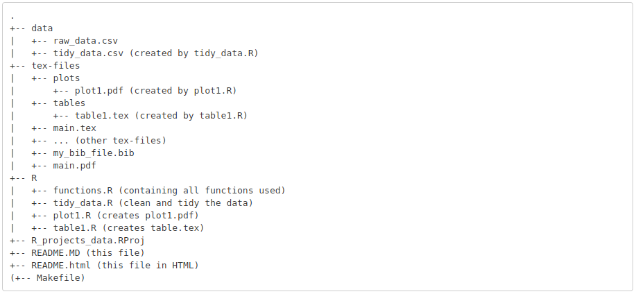

A typical file(folder)-structure for a reproducible research project

Pro tip: Write a `README.txt` file, where you describe what you are doing, what file-system you have, what is needed for redoing the calculations etc.

# Project Organization cont’d

2. Use scripts: one script for functions, separate data wrangling from analysis/visualizations (`source()` is your friend -> `?source`). This allows you to easily find parts and redo calculations. I.e.,

`functions.R`

```r
myFun <- function(){
  print("Hello World!")
}
```

`analysis.R`

```r
source("functions.R") # or source("R/functions.R")
...
myFun()
```

# Project Organization cont’d

3. Write for reproducibility (expect to do every step $\sim$ 10 times)

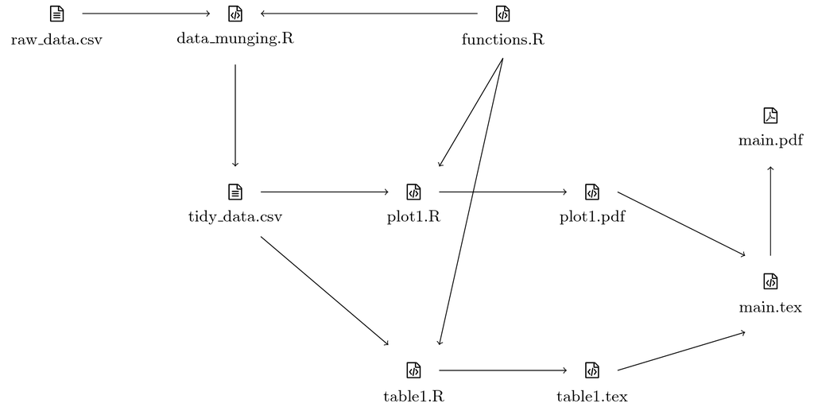

Organizational Workflow in a typical reproducible research context

# Working Directories and Projects

Working Directories (where the program looks for files and where it saves them)

```r
getwd() # get working directory

setwd("C:/.../myProject/") # set working directory
setwd("~/.../myProject/")
```

Alternative: R-projects in RStudio (topright)

Working directory is always where the project is saved

# Exercises: Style & Organization

Clean up the following code:

```r
standardize.Vector.=function(v)
{x=v-mean(v)
return(x/sd(x))
vec=rnorm(1000,mean= 100, sd< -13)
x <-standardize.Vector.(v=seq(0, 100,length.out=13));
```

An organize the code into different files (where necessary), additionally, comment the code where needed.

# Useful Information

# Useful links for base-r

- https://www.rstudio.com/wp-content/uploads/2016/09/r-cheat-sheet-1.pdf
- http://www.statmethods.net/
- http://www.cookbook-r.com/
- http://www.urfie.net/read/mobile/index.html
- http://www2.warwick.ac.uk/fac/sci/statistics/staff/academic-research/reed/rexercises.pdf

# Learning R elsewhere

- http://swirlstats.com/students.html
- http://tryr.codeschool.com
- https://cran.r-project.org/doc/contrib/Torfs+Brauer-Short-R-Intro.pdf
- https://www.datacamp.com/courses/free-introduction-to-r/
- https://www.rstudio.com/online-learning/#R
- http://www.ats.ucla.edu/stat/r/
- https://cran.r-project.org/doc/manuals/r-release/R-intro.pdf
- Hadley’s Data Science: http://r4ds.had.co.nz/
- Reproducible Resarch: http://kbroman.org/pages/tutorials.html